# Rapid and temporal methods

Block 7 · exercises 17 – 18

Sensometrics in R · SaIT

## Why rapid methods?

|  | descriptive profile | CATA | napping |
| --- | --- | --- | --- |
| assessors | 8 – 12 trained | 40 – 100 consumers | 15 – 50 |
| preparation | months of training | none | none |
| task | intensity of descriptors | tick the applicable attributes | place samples on paper |
| analysis | ANOVA, PCA | Cochran’s Q, CA | MFA |

## CATA – Check-All-That-Apply

```r
set.seed(2024)
attributes <- c("sweet", "sour", "creamy", "fruity", "thick", "artificial")
p <- rbind(A = c(.7, .2, .8, .3, .6, .1), B = c(.3, .7, .3, .2, .2, .2),
           C = c(.6, .3, .4, .8, .3, .5), D = c(.5, .4, .6, .5, .7, .1))
colnames(p) <- attributes
cata <- expand.grid(consumer = factor(1:40), product = factor(rownames(p)))
for (a in attributes) cata[[a]] <- rbinom(nrow(cata), 1, p[as.character(cata$product), a])
counts <- sapply(attributes, function(a) tapply(cata[[a]], cata$product, sum))
counts
```

```
  sweet sour creamy fruity thick artificial
A    27    8     26     16    26          2
B    10   26     15      7     5         13
C    25    7     21     33     9         18
D    19   20     28     23    29          2
```

## Cochran’s Q test

```r
q_p <- sapply(attributes, function(a) {
  d <- data.frame(y = cata[[a]], product = cata$product, consumer = cata$consumer)
  CochranQTest(y ~ product | consumer, data = d)$p.value
})
round(q_p, 4)
```

```
     sweet       sour     creamy     fruity      thick artificial
    0.0009     0.0000     0.0164     0.0000     0.0000     0.0000
```

The counterpart of McNemar’s test for more samples: the same consumers rate all products → the consumer is a **block**.

## CATA map

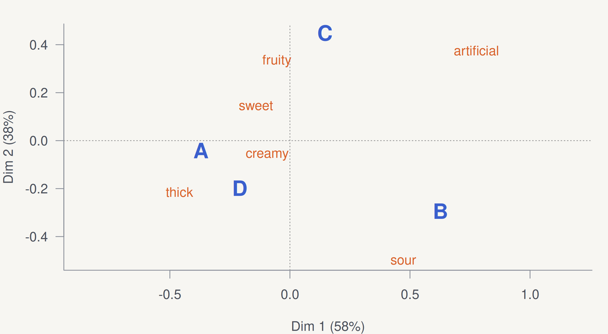

```r
ca <- CA(counts, graph = FALSE)
plot(rbind(ca$row$coord[, 1:2], ca$col$coord[, 1:2]), type = "n", asp = 1,
     xlab = sprintf("Dim 1 (%.0f%%)", ca$eig[1, 2]), ylab = sprintf("Dim 2 (%.0f%%)", ca$eig[2, 2]))
abline(h = 0, v = 0, lty = 3, col = "grey60")
text(ca$row$coord[, 1:2], rownames(counts), col = pal[3], font = 2, cex = 1.6)
text(ca$col$coord[, 1:2], colnames(counts), col = pal[2])
```

## Napping – projective mapping

- all samples at once, a 60 × 40 cm sheet
- similar samples close, different ones far apart
- X, Y coordinates are recorded
- every assessor = a group of 2 variables → **MFA**

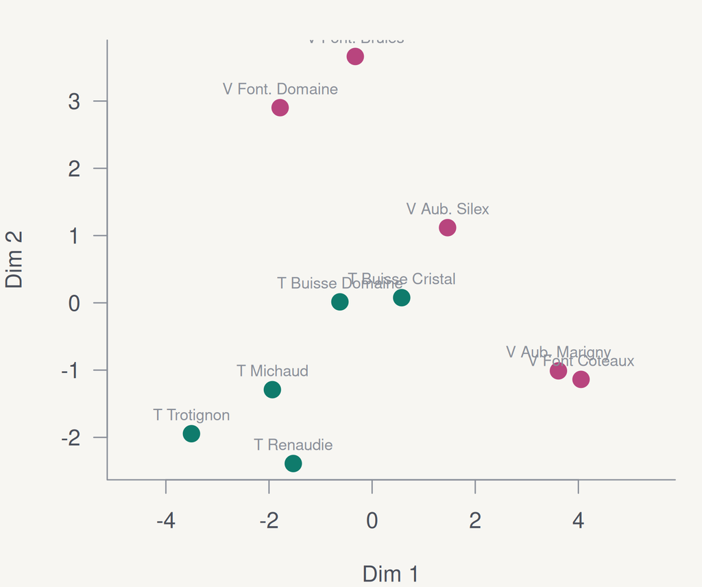

Consensus map of 10 wines: MFA balances the assessors and finds a common configuration. Green = Touraine, purple = Vouvray.

## QUIZ Scale the coordinates?

In MFA for napping we use `type = "c"` (unscaled). Why not `"s"`?

The coordinates are in **centimetres on the same sheet** – a distance of 5 cm in X and in Y means the same degree of difference. Scaling would distort this information.

## Perception changes over time

|  | TDS | TCATA |
| --- | --- | --- |
| question | which sensation is **dominant now**? | which sensations do you **perceive now**? |
| choice | exactly one attribute | any number |
| output | dominance rate | citation proportion |

Data are collected by the apps `TDS_app.R` and `TCATA_app.R` in the `Senzometricke_appky/` folder.

## TDS curves

```r
set.seed(18)
atr <- c("sweet", "sour", "bitter", "fruity", "astringent"); time <- 0:60; n <- 30
weight <- cbind(dnorm(time, 8, 8), dnorm(time, 18, 8), dnorm(time, 40, 12), dnorm(time, 22, 10), dnorm(time, 52, 10))
tds <- t(sapply(1:n, function(h) apply(weight, 1, function(w) sample(atr, 1, prob = w + 1e-4))))
dom <- sapply(atr, function(a) colMeans(tds == a))
limit <- 0.2 + 1.645 * sqrt(0.2 * 0.8 / n)
matplot(time, dom, type = "l", lty = 1, lwd = 3, col = pal, ylim = c(0, 1), xlab = "time (s)", ylab = "dominance rate")
abline(h = c(0.2, limit), lty = c(3, 2), col = c("grey50", pal[2]))
legend("topright", atr, col = pal, lwd = 3, bty = "n", cex = 0.8)
```

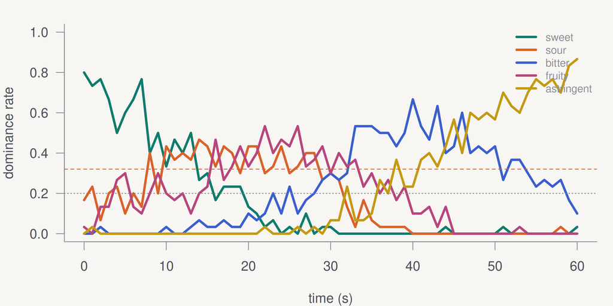

An attribute is significantly dominant above the red limit P₀ + 1.645·√(P₀(1 − P₀)/n) = 0.32.

## TCATA: comparing two products

- curves of both products in one plot
- Fisher’s test of the citation proportion at every time point
- consider a difference only over a **continuous interval**, not isolated points (dozens of tests!)

With real data assessors swallow at different times → time is often **standardised** (0 = first selection, 1 = end of recording). See the `tempR` package.

## Summary

- **CATA**: binary data → Cochran’s Q (differences), CA (map).
- **Napping**: X, Y coordinates → MFA, consensus map.
- **TDS / TCATA**: curves over time, significance limit, beware of multiple testing.
- Rapid methods: less precise, but cheap and fast – ideal for screening.

Theory 17 Theory 18